# 206.1. Deblender outputs

For the Rubin Science Platform at data.lsst.cloud.  
Data Release: DP1  
Container Size: Large  
LSST Science Pipelines version: Weekly v29.2.0  
Last verified to run: 2025-10-22  
Repository: github.com/lsst/tutorial-notebooks

**Learning objective:** This notebook demonstrates the meaning and basic use of deblender data products cataloged in the `Object` table.

**LSST data products:** `Object` table, `deep_coadd`

**Packages:** `lsst.rsp`, `lsst.daf.butler`, `lsst.geom`, `lsst.afw.display`

**Credit:** Originally developed by Christina Williams and the Rubin Community Science team. This notebook is partly based on DP0.2 notebook 10 on deblender data products, and benefited from helpful discussions with Fred Moolekamp. The deblender packages are based on [Melchior et al. 2018](https://ui.adsabs.harvard.edu/abs/2018A%26C....24..129M/abstract), and the [Scarlet software](https://pmelchior.github.io/scarlet/) written by Peter Melchior and Fred Moolekamp. Further documentation on Scarlet is available at that site.

**Get Support:** Everyone is encouraged to ask questions or raise issues in the [Support Category](https://community.lsst.org/c/support) of the Rubin Community Forum. Rubin staff will respond to all questions posted there.

## 1. Introduction

This notebook is an introduction to the data products in the `Object` table that are associated with the deblending process.

In order to build its source catalog and measure photometry of objects in images, the LSST Science Pipeline uses the multi-wavelength deblending algorithm Scarlet ([Melchior et al. 2018](https://ui.adsabs.harvard.edu/abs/2018A%26C....24..129M/abstract)) to identify independent detected components within source blends and separate the flux from independent objects.

A "**parent**" source is identified as a region of connected pixels above a given signal-to-noise ratio (S/N) in the `deepCoadd` image. These regions are called footprints. Each footprint may have one or more peaks, which the deblender uses to infer the number and positions of objects blended in each footprint. The deblended sub-peaks are referred to as "**children**" of the parent in the properties saved by the deblender in the `Object` table.

The Scarlet deblender separates the flux among components by modeling the flux and shape of each source making up the blend.

This tutorial will identify a heavily blended parent object with many children and explore how to interpret the deblender-related measurements in the `Object` table. It will also demonstrate how to use deblender-related columns in the `Object` table to identify unique deblended child sources, and provide an example of how to access metadata that is available for each deblended source (e.g. the deblended footprints and pixel-weight maps).

**Note**: There have been updates to the deblending implementation since DP1 so *expect the API to be slightly different (improved) in future data releases*, including having more information available to understand how blended an object is with its neighbors and useful cuts to remove potentially more difficult blends from analysis.

**References:**

- An introduction to all of the available deblending flags, and the processes that produce the deblender data products discussed in this tutorial can be found in this [overview of the deblending flags](https://pipelines.lsst.io/modules/lsst.pipe.tasks/deblending-flags-overview.html).
- A general discussion of blending impacts to LSST can be found in this article titled "[The challenge of blending in large sky surveys](https://lss.fnal.gov/archive/2021/pub/fermilab-pub-21-598-ppd.pdf)" by Melchior et al. 2021.
- Some more in-depth presentations on the deblending implementation in the LSST Science Pipelines are available from recorded talks during the Rubin Project and Community Workshop 2022's session on "[Deblending Plans and Challenges](https://project.lsst.org/meetings/rubin2022/agenda/deblending-plans-and-challenges)".

**Related tutorials:** A notebook demonstrating how to work with blend footprints is available as 206.2 Deblender footprints.

### 1.1. Import packages

The [matplotlib](https://matplotlib.org/) (and especially sublibrary `matplotlib.pyplot`), [numpy](http://www.numpy.org/), and [astropy](http://www.astropy.org/) libraries are widely used Python libraries for plotting, scientific computing, and astronomical data analysis.

The `lsst.rsp` package provides access to the Table Access Protocol (TAP) service for queries to the DP0 catalogs.

The `lsst.afw.display` library provides access to image visualization routines and the `lsst.daf.butler` library is used to access data products via the butler.

```python
import numpy as np
import matplotlib.pyplot as plt

from lsst.daf.butler import Butler

from lsst.rsp import get_tap_service
import lsst.geom as geom
import lsst.afw.display as afwDisplay
```

### 1.2. Define functions and parameters

The following `cutout_coadd` function enables the visualization of deblended products by making a cutout.

```python
def cutout_coadd(butler, ra, dec, band='r', datasetType='deepCoadd',
                 skymap=None, cutoutSideLength=51, **kwargs):
    """
    Produce a cutout from a coadd at the given ra, dec position.

    Adapted from DC2 tutorial notebook by Michael Wood-Vasey.

    Parameters
    ----------
    butler: lsst.daf.persistence.Butler
        Helper object providing access to a data repository
    ra: float
        Right ascension of the center of the cutout, in degrees
    dec: float
        Declination of the center of the cutout, in degrees
    band: string
        Filter of the image to load
    datasetType: string ['deepCoadd']
        Which type of coadd to load.  Doesn't support 'calexp'
    skymap: lsst.afw.skyMap.SkyMap [optional]
        Pass in to avoid the Butler read.  Useful if you have lots of them.
    cutoutSideLength: float [optional]
        Size of the cutout region in pixels.

    Returns
    -------
    MaskedImage
    """
    radec = geom.SpherePoint(ra, dec, geom.degrees)
    cutoutSize = geom.ExtentI(cutoutSideLength, cutoutSideLength)

    if skymap is None:
        skymap = butler.get("skyMap")

    tractInfo = skymap.findTract(radec)
    patchInfo = tractInfo.findPatch(radec)
    xy = geom.PointI(tractInfo.getWcs().skyToPixel(radec))
    bbox = geom.BoxI(xy - cutoutSize // 2, cutoutSize)
    print("bbox = ", bbox, "xy = ", xy, "cutoutSize = ", cutoutSize)
    patch = tractInfo.getSequentialPatchIndex(patchInfo)
    tract = tractInfo.getId()

    parameters = {'bbox': bbox}

    query = """band.name = '{}' AND patch = {} AND tract = {}
        """.format('i', patch, tract)
    print(query)

    dataset_refs = butler.query_datasets("deep_coadd", where=query)

    cutout_image = butler.get(dataset_refs[0], parameters=parameters)

    return cutout_image
```

Set the backend for afwDisplay to matplotlib.

```python
afwDisplay.setDefaultBackend('matplotlib')
```

Get an instance of the TAP service, and assert that it exists.

```python
service = get_tap_service("tap")
assert service is not None
```

Instantiate the butler.

```python
butler = Butler('dp1', collections="LSSTComCam/DP1")
assert butler is not None
```

## 2. The deblender data products

The object catalog contains a number of columns that can be used to identify and characterize blended objects in the `deepCoadd` images. Prior to deblending, blends are identified (referred to as parents), and are then deblended into child objects by the LSST deblender package, Scarlet Lite. Only the children are ultimately stored in the `Object` table; the parent objects are excluded. Of course, isolated single sources that do not require deblending are also stored in the `Object` table and are not considered parent sources.

In this tutorial we will focus on the deblending data products for objects stored in the `Object` table.

The following describes key parameters in the `Object` table: 1) boolean flags that are set by the deblender, Scarlet Lite; 2) measurements or properties of deblended sources that can be used to characterize (de)blended sources; 3) blendedness metrics performed after the deblender completes; 4) obsolete keywords still present in the `Object` table.

Scarlet blend flags:

`detect_fromBlend` (boolean): If True, this source is deblended from a parent with more than one child.

`detect_isIsolated` (boolean): If True, this source was not part of a blend.

Scarlet Lite blend measurements:

`parentObjectId` (long): Unique ID of parent source.

`footprintArea` (int): Number of pixels in the deblended object's detection "footprint", in the "reference band".

`<f>_deblend_fluxOverlap` (dbl): The total flux from neighboring objects that overlaps with this sources footprint in the deconvolved space. See also `<f>_deblend_fluxOverlapFraction` Fraction of flux from neighbors / source flux in the deconvolved footprint.

Blendedness parameters:

`<f>_blendedness` (dbl): For each filter (f = u, g, r, i, z, or y), a measure of how much the flux is affected by neighbors, (1 - child_flux/parent_flux). The measurement is in the observed, not point spread function (PSF)-deconvolved space. Operates on the absolute value of the pixels to try to obtain a de-noised value. These are not performed by the deblender (Scarlet Lite) but rather from a blendedness algorithm (see section 4.9.11 of [Bosch et al. 2018, PASJ, 70, S5](https://ui.adsabs.harvard.edu/abs/2018PASJ...70S...5B/abstract) for details).

`<f>_deblend_blendedness` (dbl): Blendedness in filter in the PSF-deconvolved space.

`<f>_blendedness_flag` (boolean): Flag set for any failure in the blendedness algorithm.

Obsolete or non-informative parameters:

`deblend_failed` (boolean): Deblender failed to deblend this source. Note that in DP1, only child objects that were successfully deblended will appear in the `Object` table. Thus, parent objects which failed to deblend are not included, and this flag is always 0. In future data releases, a parent catalog may exist with informative keywords for the deblender's performance.

In addition to `deblend_failed`, the following columns from DP0.2 have now been deprecated, although still appear in the `Object` table (artifacts from when the parents were included in the same catalog). This includes `deblend_nChild`, which was a property of parents but does not contain useful information in DP1 because the parent blends themselves are now excluded from the `Object` table. Similarly, `deblend_nPeaks`, which used to contain the number of peaks a parent object has in DP0.2, still appears in DP1, but always contains the value 1 because only child objects are in the `Object` table.

### 2.1. Identify blended objects

As with all explorative TAP queries searching for examples, it is essential to first start with a small area while developing queries (to confirm the query is good), and then iteratively increase the area as needed (because the full query could take hours without any spatial constraint on the search). This is because the tables are indexed by Right Ascension and declination coordinates (R.A., Dec) and queries with constraints only on measurement columns (such as deblending-related parameters) are inefficient. In other words, Qserv (the backend hosting the TAP-accessible tables) is "spatially sharded".

Set the location for the query to be in the center of the Extended Chandra Deep Field South (ECDFS) field.

```python
ra = 53.2
dec = -28.1
```

Query for objects in a small region of ECDFS for exploration of the deblender data products stored in the `Object` table.

```python
query = "SELECT objectId, coord_ra, coord_dec, x, y, tract, patch, " + \
        "refExtendedness, detect_fromBlend, detect_isIsolated, " + \
        "parentObjectId, deblend_failed, i_deblend_fluxOverlapFraction, " + \
        "footprintArea, i_blendedness, i_deblend_blendedness, i_blendedness_flag " + \
        "FROM dp1.Object " + \
        "WHERE CONTAINS(POINT('ICRS', coord_ra, coord_dec ), " + \
        "CIRCLE('ICRS', " + str(ra) + ", " + str(dec) + ", .1)) = 1 "
```

Run the TAP query.

```python
job = service.submit_job(query)
job.run()
job.wait(phases=['COMPLETED', 'ERROR'])
print('Job phase is', job.phase)
```

```
Job phase is COMPLETED
```

Store the resulting objects and columns from the `Object` table to a table called results.

```python
assert job.phase == 'COMPLETED'
results = job.fetch_result().to_table()
```

### 2.2. Identify isolated objects

A sample of objects that are not near any neighbors, and therefore were not deblended, can be identified using the `detect_isIsolated` keyword. Similarly, a set of objects that were identified as part of a blend can be identified using the `detect_fromBlend` keyword.

```python
whiso = np.where(results['detect_isIsolated'] == 1)[0]
whblend = np.where(results['detect_fromBlend'] == 1)[0]
```

Generate a cutout of the i-band `deep_coadd` imaging that overlaps the queried objects, centered at (RA, Dec) = 53.11, -28.07 degrees, with a cutout edge size of 200 pixels.

```python
cutout = cutout_coadd(butler, 53.11, -28.07,
                      band='i', datasetType='deepCoadd',
                      cutoutSideLength=200)
```

```
bbox =  (minimum=(14543, 5011), maximum=(14742, 5210)) xy =  (14643, 5111) cutoutSize =  (200, 200)
band.name = 'i' AND patch = 14 AND tract = 5063
```

Display the cutout with isolated objects identified by red circles and objects that were identified from blends identified as cyan plus signs. To ensure that `afwDisplay` will make the low surface brightness connecting the blends together visible, set the scale to linear, set the min and max pixel values to be relatively low and also indicate with units=Absolute that these should be in actual count units.

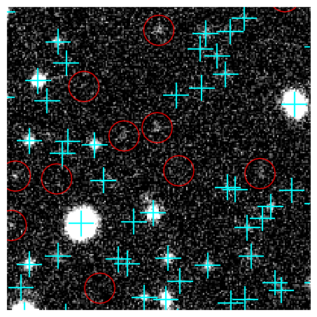

```python
fig = plt.figure(figsize=(6, 6))
display = afwDisplay.Display(frame=fig)

display.scale('linear', min=0.1, max=10, unit='Absolute')

display.mtv(cutout.image)
with display.Buffering():
    for ci in range(len(whiso)):
        display.dot('o', results['x'][whiso][ci], results['y'][whiso][ci],
                    size=10, ctype=afwDisplay.RED)
    for ci in range(len(whblend)):
        display.dot('+', results['x'][whblend][ci], results['y'][whblend][ci],
                    size=8, ctype=afwDisplay.CYAN)
plt.gca().axis('off')
display.show_colorbar(False)
plt.show()
```

> **Figure 1:** The cutout image displayed in greyscale, with cyan + marking objects that are blended in the `deep_coadd`, red circles marking objects that are isolated (and is not part of a blend).

## 3. Explore blended objects

Use the TAP service to find a group of objects that were heavily blended and part of the same parent object.

### 3.1. Blend with several children

First, identify a set of unique `parentObjectIds`, and the number of objects that are deblended from those `parentObjectId`s, (stored as `counts`). Then, select as an example a blend that was made up of 15 children.

To identify the most blended object in the query, replace the second code line with: `most_common_index_in_unique = np.argmax(counts)`

```python
unique_IDs, counts = np.unique(results['parentObjectId'], return_counts=True)

most_common_index_in_unique = np.where(counts == 15)[0]

most_common_value = unique_IDs[most_common_index_in_unique[0]]

whparent = np.where(results['parentObjectId'] == most_common_value)[0]
max_parentId = results['parentObjectId'][whparent][0]
```

Use TAP to retrieve all children for the selected parent.

```python
query = "SELECT objectId, coord_ra, coord_dec, x, y, parentObjectId, i_blendedness_flag, " + \
        "i_cModelFlux/i_cModelFluxErr AS i_S2N, footprintArea, i_deblend_blendedness, " + \
        "i_blendedness, deblend_failed, i_deblend_fluxOverlap, i_deblend_fluxOverlapFraction " + \
        "FROM dp1.Object " + \
        "WHERE CONTAINS(POINT('ICRS', coord_ra, coord_dec ), " + \
        "CIRCLE('ICRS', " + str(ra) + ", " + str(dec) + ", .1)) = 1 " + \
        "AND parentObjectId = " + str(max_parentId)
```

Run the TAP query.

```python
job = service.submit_job(query)
job.run()
job.wait(phases=['COMPLETED', 'ERROR'])
print('Job phase is', job.phase)
```

```
Job phase is COMPLETED
```

Store the query results in a table called children.

```python
assert job.phase == 'COMPLETED'
children = job.fetch_result().to_table()
children
```

*Table length=15*

| objectId int64 | coord_ra deg float64 | coord_dec deg float64 | x pix float64 | y pix float64 | parentObjectId int64 | i_blendedness_flag bool | i_S2N float64 | footprintArea pix int32 | i_deblend_blendedness float32 | i_blendedness float32 | deblend_failed bool | i_deblend_fluxOverlap float32 | i_deblend_fluxOverlapFraction float32 |
| --- | --- | --- | --- | --- | --- | --- | --- | --- | --- | --- | --- | --- | --- |
| 611254316728073284 | 53.294864915499765 | -28.126076964734423 | 11707.922594133186 | 4098.302973641447 | 611254316728059699 | False | 7.096778393068185 | 1127 | 0.0 | 0.0466138 | False | 0.0 | 0.0 |
| 611254316728073280 | 53.30000004299527 | -28.127485719212654 | 11626.443568882292 | 4072.8016766671863 | 611254316728059699 | False | 7.809782722792145 | 597 | 0.0 | 0.0271333 | False | 0.0 | 0.0 |
| 611254316728073281 | 53.29739851633408 | -28.127993986892044 | 11667.758939611198 | 4063.7235506255665 | 611254316728059699 | True | -0.019130034522410754 | 454 | 0.0 | -- | False | 0.0 | 0.0 |
| 611254316728073282 | 53.296165745419366 | -28.128734914905575 | 11687.351831657825 | 4050.4189893817747 | 611254316728059699 | False | 7.423539277962396 | 1162 | 0.0246679 | 0.266039 | False | 3.46231 | 0.0168952 |
| 611254316728073283 | 53.29660129461913 | -28.125536808717257 | 11680.340399977047 | 4107.979685606347 | 611254316728059699 | False | 7.419048613431707 | 881 | 0.0 | 0.0227583 | False | 0.0 | 0.0 |
| 611254316728073279 | 53.295658871229705 | -28.125294285218384 | 11695.29454317496 | 4112.371287173421 | 611254316728059699 | True | -0.06455831873487836 | 422 | 0.0 | -- | False | 0.0 | 0.0 |
| 611254316728073285 | 53.2967491477205 | -28.129172760001698 | 11678.103579404262 | 4042.5209388886897 | 611254316728059699 | True | 6.25844073372527 | 993 | 0.0102184 | 0.103867 | False | 38.0434 | 0.196383 |
| 611254316728073286 | 53.29294969335254 | -28.12786049935853 | 11738.380787078966 | 4066.2472628100695 | 611254316728059699 | False | 5.4996531838805645 | 388 | 0.0 | 0.057179 | False | 0.0 | 0.0 |
| 611254316728073287 | 53.29414955777493 | -28.126644370416713 | 11719.296237432669 | 4088.1078306569243 | 611254316728059699 | False | 3.561928011397123 | 608 | 0.0 | 0.618377 | False | 0.0 | 0.0 |
| 611254316728073273 | 53.29566789404083 | -28.127286563178075 | 11695.211494752568 | 4076.505898078906 | 611254316728059699 | False | 983.0246787788672 | 3793 | 0.00166738 | 0.00233513 | False | 2336.91 | 0.059042 |
| 611254316728073274 | 53.29411430010412 | -28.127641516595084 | 11719.885868289113 | 4070.158073828561 | 611254316728059699 | False | 180.3119748899455 | 2401 | 0.048463 | 0.0133469 | False | 5735.77 | 0.996521 |
| 611254316728073275 | 53.299318362969274 | -28.127070560818673 | 11637.252647255584 | 4080.2942815238393 | 611254316728059699 | False | 29.476632628687174 | 898 | 0.0 | 0.00107619 | False | 0.0 | 0.0 |
| 611254316728073276 | 53.29821288343833 | -28.12659024085694 | 11654.787788395472 | 4088.971541652779 | 611254316728059699 | False | 13.644255885327834 | 848 | 0.0 | 0.000571488 | False | 0.0 | 0.0 |
| 611254316728073277 | 53.29420641670363 | -28.12891471823645 | 11718.46169470667 | 4047.235296448674 | 611254316728059699 | False | 11.529717469086624 | 904 | 0.0 | 0.00755404 | False | 0.0 | 0.0 |
| 611254316728073278 | 53.29670099675805 | -28.128213784960245 | 11678.83885814897 | 4059.7858143524772 | 611254316728059699 | False | 9.164728767215426 | 1381 | 0.0115476 | 0.0656418 | False | 33.8051 | 0.16126 |

The table above confirms that the children returned by the query were deblended from the same parent source, since they all show the same `parentObjectId`.

Below, identify this child with heavy blendedness of 50%.

```python
whheavy = np.where(children['i_blendedness'] > 0.5)[0]

children[whheavy]
```

*Table length=1*

| objectId int64 | coord_ra deg float64 | coord_dec deg float64 | x pix float64 | y pix float64 | parentObjectId int64 | i_blendedness_flag bool | i_S2N float64 | footprintArea pix int32 | i_deblend_blendedness float32 | i_blendedness float32 | deblend_failed bool | i_deblend_fluxOverlap float32 | i_deblend_fluxOverlapFraction float32 |
| --- | --- | --- | --- | --- | --- | --- | --- | --- | --- | --- | --- | --- | --- |
| 611254316728073287 | 53.29414955777493 | -28.126644370416713 | 11719.296237432669 | 4088.1078306569243 | 611254316728059699 | False | 3.561928011397123 | 608 | 0.0 | 0.618377 | False | 0.0 | 0.0 |

Next, visualize these test cases along with the other child sources of this `parentObjectId`. Use the `cutout_coadd` function to obtain a cutout image to visualize the blend. Set the size of the cutout to be 2x the square root of the `footprintArea`.

```python
cutout = cutout_coadd(butler, children['coord_ra'][0],
                      children['coord_dec'][0],
                      band='i', datasetType='deepCoadd',
                      cutoutSideLength=2.0
                      * np.sqrt(np.sum(children['footprintArea'])))
```

```
bbox =  (minimum=(11579, 3969), maximum=(11837, 4227)) xy =  (11708, 4098) cutoutSize =  (259, 259)
band.name = 'i' AND patch = 13 AND tract = 5063
```

Display the `deepCoadd` cutout made for this parent, with all deblended children identified with red circles. Identify the children for which the blendedness metric (before deblending) was 50% with a cyan circle.

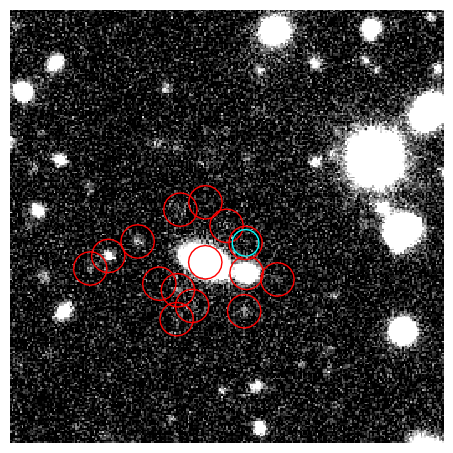

```python
fig = plt.figure(figsize=(6, 6))
display = afwDisplay.Display(frame=fig)
display.scale('linear', min=0.1, max=10, unit='Absolute')
display.mtv(cutout.image)
with display.Buffering():
    for ci in range(len(children)):
        display.dot('o', children['x'][ci], children['y'][ci],
                    size=10, ctype=afwDisplay.RED)

    for ci in range(len(whheavy)):
        display.dot('o', children['x'][whheavy][ci], children['y'][whheavy][ci],
                    size=8, ctype=afwDisplay.CYAN)

plt.gca().axis('off')
display.show_colorbar(False)
plt.show()
```

> **Figure 2:** The cutout image displayed in greyscale, with red circles marking the deblended children, cyan circles indicating any children whose contamination from neighbors prior to deblending is high (>50% of flux from a neighbor).

## 4. Heavy blends

It is useful to be able to quantify how much flux in the blended source is attributed to a neighbor. [Mandelbaum et al. 2018](https://ui.adsabs.harvard.edu/abs/2018PASJ...70S..25M/abstract) quantitatively explored the criteria for acceptable blendedness as a metric of deblender performance. In this section, explore examples where sources are heavily contaminated (`<f>_blendedness` >50%) by the flux of neighbors, and then compare to the deblended contamination fraction `<f>_deblend_blendedness`.

Below, identify which child objects are above this high threshold of PSF-convolved blending, and see what fraction of objects in the catalog meet this criteria.

```python
whheavy = np.where(results['i_blendedness'] > 0.5)[0]

print('Fraction of objects that are heavily blended is', len(whheavy)/len(results))

results[whheavy]
```

```
Fraction of objects that are heavily blended is 0.05161951296398455
```

*Table length=655*

| objectId int64 | coord_ra deg float64 | coord_dec deg float64 | x pix float64 | y pix float64 | tract int64 | patch int64 | refExtendedness float32 | detect_fromBlend bool | detect_isIsolated bool | parentObjectId int64 | deblend_failed bool | i_deblend_fluxOverlapFraction float32 | footprintArea pix int32 | i_blendedness float32 | i_deblend_blendedness float32 | i_blendedness_flag bool |
| --- | --- | --- | --- | --- | --- | --- | --- | --- | --- | --- | --- | --- | --- | --- | --- | --- |
| 611254385447544690 | 53.13519969736965 | -28.174235673721885 | 14243.0 | 3234.0 | 5063 | 14 | -- | True | False | 611254385447535007 | False | 0.0 | 858 | 0.63383 | 0.0 | True |
| 611254385447544895 | 53.16954039531234 | -28.17252054301108 | 13698.049997594719 | 3264.585313575522 | 5063 | 14 | 1.0 | True | False | 611254385447535046 | False | 0.119499 | 4055 | 0.76188 | 0.0280823 | True |
| 611254385447544701 | 53.13909983521877 | -28.171548745179557 | 14181.09123568142 | 3282.3456989457572 | 5063 | 14 | 0.0 | True | False | 611254385447535007 | False | 0.0 | 822 | 0.792746 | 0.0 | True |
| 611254385447544700 | 53.134389433643335 | -28.167761350058857 | 14255.813508404724 | 3350.557868673939 | 5063 | 14 | 1.0 | True | False | 611254385447535007 | False | 0.0 | 729 | 0.716964 | 0.0 | True |
| 611254385447544698 | 53.13850187710381 | -28.173417218421353 | 14190.593883021484 | 3248.7128267156313 | 5063 | 14 | 0.0 | True | False | 611254385447535007 | False | 0.0187774 | 866 | 0.915677 | 0.0 | True |
| 611254385447544694 | 53.13380665572926 | -28.173724973282084 | 14265.101808316345 | 3243.202357150687 | 5063 | 14 | 0.0 | True | False | 611254385447535007 | False | 0.278963 | 869 | 0.92557 | 0.163778 | False |
| 611254385447544675 | 53.19670306512206 | -28.18155054742929 | 13267.15963472656 | 3101.684287959478 | 5063 | 14 | 1.0 | True | False | 611254385447535002 | False | 0.261363 | 1187 | 0.551983 | 0.0273822 | True |
| 611254385447544856 | 53.16954552878979 | -28.17516382339935 | 13698.0 | 3217.0 | 5063 | 14 | -- | True | False | 611254385447535046 | False | 0.0 | 628 | 0.623825 | 0.0 | True |
| 611254385447544755 | 53.1291553804536 | -28.168057824906295 | 14338.87587132155 | 3345.2508989383327 | 5063 | 14 | 1.0 | True | False | 611254385447535007 | False | 0.0 | 2007 | 0.942302 | 0.0 | False |
| ... | ... | ... | ... | ... | ... | ... | ... | ... | ... | ... | ... | ... | ... | ... | ... | ... |
| 611255072642313311 | 53.20135382982996 | -28.00308313440975 | 13190.41616532324 | 6314.355895507243 | 5063 | 24 | 1.0 | True | False | 611255072642302463 | False | 0.195938 | 3597 | 0.51361 | 0.0144362 | True |
| 611255072642313307 | 53.20305462949681 | -28.003898693687166 | 13163.398676693096 | 6299.649372705893 | 5063 | 24 | 0.0 | True | False | 611255072642302463 | False | 0.0 | 729 | 0.904063 | 0.0 | False |
| 611255072642313305 | 53.2040834630872 | -28.001100774123767 | 13147.0 | 6350.0 | 5063 | 24 | -- | True | False | 611255072642302463 | False | 0.178627 | 1130 | 0.955346 | 0.0516371 | True |
| 611255072642313291 | 53.20333921739306 | -28.001937605008926 | 13158.842732628122 | 6334.947224300739 | 5063 | 24 | 1.0 | True | False | 611255072642302463 | False | 0.0511759 | 5759 | 0.517831 | 0.0115761 | False |
| 611255072642313345 | 53.20050844124145 | -28.001059701248867 | 13203.81892215245 | 6350.792787047805 | 5063 | 24 | 1.0 | True | False | 611255072642302463 | False | 0.935601 | 2315 | 0.612822 | 0.0641272 | False |
| 611255072642313254 | 53.16952643016269 | -28.004336258414668 | 13696.270205163804 | 6292.203801692791 | 5063 | 24 | 0.0 | True | False | 611255072642302460 | False | 0.0 | 425 | 1.0 | 0.0 | True |
| 611255072642313173 | 53.17559191610622 | -28.012925919489923 | 13599.981173061438 | 6137.511430904762 | 5063 | 24 | 0.0 | True | False | 611255072642302420 | False | 0.0 | 497 | 0.838909 | 0.0 | True |
| 611255072642313168 | 53.22162746435075 | -28.010456547280043 | 12868.3464339552 | 6181.297456474858 | 5063 | 24 | 1.0 | True | False | 611255072642302408 | False | 0.0 | 368 | 0.751635 | 0.0 | True |
| 611255072642313209 | 53.156019159072066 | -28.01024339249967 | 13911.0 | 6186.0 | 5063 | 24 | -- | True | False | 611255072642302438 | False | 0.0 | 508 | 1.0 | 0.0 | False |

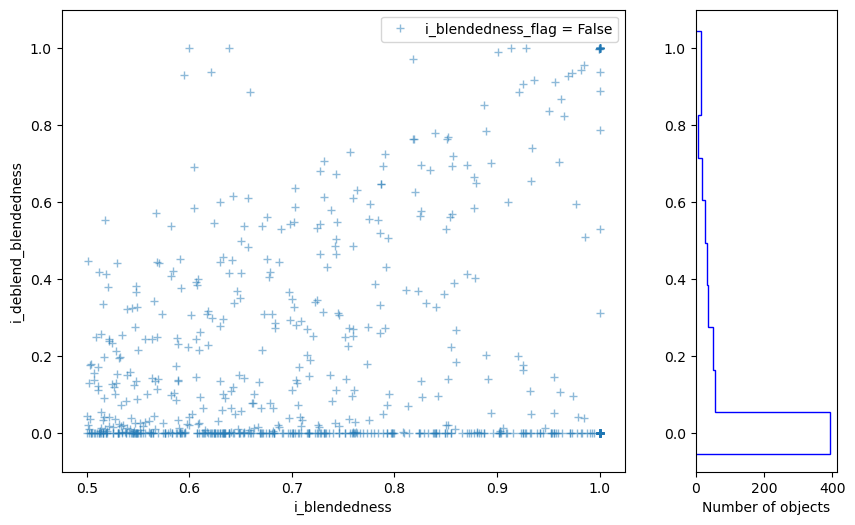

```python
fig, (ax, ax2) = plt.subplots(ncols=2, nrows=1,
                              width_ratios=[0.8, 0.2], figsize=(10, 6))

ax.plot(results['i_blendedness'][whheavy], results['i_deblend_blendedness'][whheavy],
        '+', alpha=0.5, label='i_blendedness_flag = False')

ax2.hist((results['i_deblend_blendedness'][whheavy]), orientation="horizontal",
         bins=np.linspace(0, 1.1, 11), align='left',
         histtype="step", color='blue', stacked=True, fill=False, label=None)

ax.legend()
ax.set_ylim([-0.1, 1.1])
ax2.set_ylim([-0.1, 1.1])
ax.set_xlabel('i_blendedness')
ax.set_ylabel('i_deblend_blendedness')
ax2.set_xlabel('Number of objects')
plt.show()
```

Below, take a closer look at the objects for which the deblender did not effectively separate the flux from neighbors.

```python
wh = np.where((results['i_blendedness'][whheavy] == 1)
              & (results['i_deblend_blendedness'][whheavy] == 1))[0]
results[whheavy][wh]
```

*Table length=7*

| objectId int64 | coord_ra deg float64 | coord_dec deg float64 | x pix float64 | y pix float64 | tract int64 | patch int64 | refExtendedness float32 | detect_fromBlend bool | detect_isIsolated bool | parentObjectId int64 | deblend_failed bool | i_deblend_fluxOverlapFraction float32 | footprintArea pix int32 | i_blendedness float32 | i_deblend_blendedness float32 | i_blendedness_flag bool |
| --- | --- | --- | --- | --- | --- | --- | --- | --- | --- | --- | --- | --- | --- | --- | --- | --- |
| 611254385447544541 | 53.20949616587542 | -28.172079076941582 | 13064.0 | 3272.0 | 5063 | 14 | -- | True | False | 611254385447534971 | False | 3.03895e+19 | 800 | 1.0 | 1.0 | True |
| 611254385447544333 | 53.15827111350926 | -28.184446622615013 | 13877.0 | 3050.0 | 5063 | 14 | -- | True | False | 611254385447534885 | False | 4.39223e+21 | 1078 | 1.0 | 1.0 | True |
| 611254385447549206 | 53.18980321551127 | -28.119724512611672 | 13375.723811530852 | 4214.783959504233 | 5063 | 14 | 0.0 | True | False | 611254385447536499 | False | 1.13236e+20 | 381 | 1.0 | 1.0 | True |
| 611254385447549812 | 53.12049510141591 | -28.11173172929737 | 14476.038394057774 | 4359.281431858267 | 5063 | 14 | 0.0 | True | False | 611254385447536655 | False | 2.25389e+20 | 825 | 1.0 | 1.0 | True |
| 611254385447551337 | 53.08850219033574 | -28.09403090209418 | 14984.0 | 4678.0 | 5063 | 14 | -- | True | False | 611254385447537140 | False | 1.46538e+21 | 715 | 1.0 | 1.0 | True |
| 611254385447553259 | 53.14641831409112 | -28.059632707558045 | 14064.0 | 5297.0 | 5063 | 14 | -- | True | False | 611254385447537876 | False | 1.92496e+20 | 590 | 1.0 | 1.0 | True |
| 611254385447552110 | 53.17513260519447 | -28.079017674217436 | 13608.120706299507 | 4947.76417469945 | 5063 | 14 | 0.0 | True | False | 611254385447537432 | False | 2.26052e+20 | 509 | 1.0 | 1.0 | True |

Note that by selecting objects where the `i_blendedness` and `i_deblend_blendedness` metrics are high, the `i_deblend_fluxOverlapFraction` is also high. Below, pick one of the above objects which has a high value of `i_deblend_fluxOverlapFraction` as an example.

```python
max_parentId = results['parentObjectId'][whheavy][wh][3]
print(max_parentId)
```

```
611254385447536655
```

Define a TAP query that will return all children with the same `parentObjectId` as the above source.

```python
query = "SELECT objectId, coord_ra, coord_dec, x, y, parentObjectId, i_blendedness_flag, " + \
        "i_cModelFlux/i_cModelFluxErr AS i_S2N, footprintArea, i_deblend_blendedness, " + \
        "i_blendedness, deblend_failed, i_deblend_fluxOverlapFraction " + \
        "FROM dp1.Object " + \
        "WHERE CONTAINS(POINT('ICRS', coord_ra, coord_dec ), " + \
        "CIRCLE('ICRS', " + str(ra) + ", " + str(dec) + ", .1)) = 1 " + \
        "AND parentObjectId = " + str(max_parentId)
```

Run the TAP query.

```python
job = service.submit_job(query)
job.run()
job.wait(phases=['COMPLETED', 'ERROR'])
print('Job phase is', job.phase)
```

```
Job phase is COMPLETED
```

Save the results to a table named `bigblend`.

```python
assert job.phase == 'COMPLETED'
bigblend = job.fetch_result().to_table()
bigblend
```

*Table length=96*

| objectId int64 | coord_ra deg float64 | coord_dec deg float64 | x pix float64 | y pix float64 | parentObjectId int64 | i_blendedness_flag bool | i_S2N float64 | footprintArea pix int32 | i_deblend_blendedness float32 | i_blendedness float32 | deblend_failed bool | i_deblend_fluxOverlapFraction float32 |
| --- | --- | --- | --- | --- | --- | --- | --- | --- | --- | --- | --- | --- |
| 611254385447549797 | 53.1288427976875 | -28.10480712598396 | 14343.457205267834 | 4483.896967629499 | 611254385447536655 | False | 215.44854614877488 | 1163 | 0.0 | 0.00350331 | False | 0.0 |
| 611254385447549796 | 53.11888362555566 | -28.107791439571333 | 14501.6065137152 | 4430.220912669169 | 611254385447536655 | False | 250.63591035174784 | 2025 | 3.21865e-06 | 0.000266227 | False | 0.000313662 |
| 611254385447549795 | 53.11611224989274 | -28.113955866474047 | 14545.635880058906 | 4319.260279373383 | 611254385447536655 | False | 322.89613376597396 | 3663 | 0.0793223 | 0.0341204 | False | 0.506552 |
| 611254385447549794 | 53.11700075484309 | -28.1079685721846 | 14531.503430249773 | 4427.03966030183 | 611254385447536655 | False | 291.69423067404375 | 1563 | 6.4373e-06 | 0.0004873 | False | 0.00192911 |
| 611254385447549793 | 53.1180600864281 | -28.109246128997558 | 14514.68908284418 | 4404.037068458728 | 611254385447536655 | False | 348.8334477051298 | 3984 | 3.23057e-05 | 9.18724e-06 | False | 0.00858761 |
| 611254385447549792 | 53.11158995129432 | -28.097739682971145 | 14617.380160351358 | 4611.197577154995 | 611254385447536655 | False | 506.0188839436898 | 3151 | 0.000519693 | 0.000509103 | False | 0.0593205 |
| 611254385447549791 | 53.12623991171105 | -28.103492711561 | 14384.77949530281 | 4507.572471862002 | 611254385447536655 | False | 757.3897367079634 | 3508 | 0.000226974 | 0.000384537 | False | 0.00732551 |
| 611254385447549790 | 53.12814080136739 | -28.103523183723958 | 14354.596220940137 | 4507.014080406694 | 611254385447536655 | False | 1352.8618903658546 | 4672 | 6.71744e-05 | 6.82606e-05 | False | 0.0349882 |
| 611254385447549789 | 53.11828000026783 | -28.112432694459184 | 14511.211557368695 | 4346.671920236903 | 611254385447536655 | False | 2091.330592818051 | 8486 | 0.00108224 | 5.54428e-06 | False | 0.0687492 |
| ... | ... | ... | ... | ... | ... | ... | ... | ... | ... | ... | ... | ... |
| 611254385447549832 | 53.125084219842584 | -28.101914774087426 | 14403.12165942666 | 4535.984030352416 | 611254385447536655 | False | 20.910674548838095 | 1365 | 0.0 | 0.0259139 | False | 0.0 |
| 611254385447549831 | 53.113438156916516 | -28.095569206991563 | 14588.02356178145 | 4650.264074694331 | 611254385447536655 | False | 22.907193688433754 | 1065 | 0.0 | 0.0286494 | False | 0.0 |
| 611254385447549830 | 53.12218227063278 | -28.111791938258616 | 14449.250843199985 | 4358.190112733937 | 611254385447536655 | False | 34.48630226669729 | 3145 | 0.0340317 | 0.179712 | False | 0.385945 |
| 611254385447549829 | 53.1318061296595 | -28.106943745200972 | 14296.41795031805 | 4445.417256691017 | 611254385447536655 | False | 22.45457143896183 | 1127 | 0.0 | 0.0013955 | False | 0.0 |
| 611254385447549828 | 53.11686873975791 | -28.100558805740587 | 14533.568026965002 | 4560.429811437709 | 611254385447536655 | False | 23.334000662629794 | 851 | 0.0 | 0.00102294 | False | 0.0 |
| 611254385447549827 | 53.11699399268731 | -28.10543098758147 | 14531.599954931451 | 4472.72099149102 | 611254385447536655 | False | 25.66002105212157 | 916 | 0.0 | 0.00145569 | False | 0.0 |
| 611254385447549826 | 53.12571971486296 | -28.11439955931827 | 14393.099916741849 | 4311.231098268632 | 611254385447536655 | False | 27.86640540363285 | 1213 | 0.00416863 | 0.0188595 | False | 0.0386981 |
| 611254385447549825 | 53.11654664325399 | -28.110218231774027 | 14538.723255255323 | 4386.5432456915005 | 611254385447536655 | False | 36.848724531259194 | 1432 | 0.00419945 | 0.0242835 | False | 0.0636848 |
| 611254385447549824 | 53.12443454460638 | -28.101495927169392 | 14413.435494369105 | 4543.527206441226 | 611254385447536655 | False | 28.603272655627084 | 941 | 0.0 | 0.00712143 | False | 0.0 |

Use the cutout_coadd function to request an image cutout of this blend, and identify any objects which still have 1% of flux contributed by a neighbor after the deblending process (`i_deblend_blendedness` > 0.01).

```python
cutout = cutout_coadd(butler, bigblend['coord_ra'][0],
                      bigblend['coord_dec'][0],
                      band='i', datasetType='deepCoadd',
                      cutoutSideLength=2.0 * np.sqrt(np.sum(bigblend['footprintArea'])))

whheavy = np.where(bigblend['i_deblend_blendedness'] > 0.01)[0]
```

```
bbox =  (minimum=(13941, 4082), maximum=(14744, 4885)) xy =  (14343, 4484) cutoutSize =  (804, 804)
band.name = 'i' AND patch = 14 AND tract = 5063
```

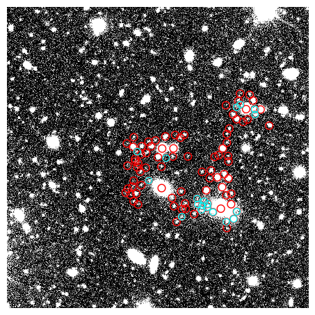

```python
fig = plt.figure(figsize=(6, 6))
display = afwDisplay.Display(frame=fig)
display.scale('linear', min=0.01, max=5, unit='Absolute')
display.mtv(cutout.image)
with display.Buffering():
    for ci in range(len(bigblend)):
        display.dot('o', bigblend['x'][ci], bigblend['y'][ci],
                    size=10, ctype=afwDisplay.RED)

    for ci in range(len(whheavy)):
        display.dot('o', bigblend['x'][whheavy][ci], bigblend['y'][whheavy][ci],
                    size=9, ctype=afwDisplay.CYAN)

plt.gca().axis('off')
display.show_colorbar(False)
plt.show()
```

> **Figure 4:** This figure shows a heavily blended parent for which deblended objects have a fraction of flux contributed by neighbors (red circles). Cyan circles indicate objects whose `deblend_blendedness` metric is not 0, and remains > 1% contamination even after deblending. They are typically faint objects near the outskirts of the biggest and brightest objects where contamination might be high.

## 5. Exercises for the learner

Use the deblender data products and blend metrics in the `Object` table to identify what fraction of sources in ECDFS are contaminated by neighbor flux at the 5% level in the observed frame? What fraction have 5% flux contamination in the PSF-deconvolved (i.e. deblended) frame?